# Data Translation Assignment Question 3

### 3.1.4 Educational Services, and Health Care and Social Assistance Industry

```r
empstatdf4 <- empstatdf %>%
  filter(indname == 'Educational Services, and Health Care and Social Assistance')

m15 <- lm(EMPSTAT ~ Date * PostCOVID, data = empstatdf4)
export_summs(m15)
```

|  | Model 1 |
| --- | --- |
| (Intercept) | 0.92 *** |
|  | (0.02) |
| Date | 0.00 * |
|  | (0.00) |
| PostCOVIDTRUE | -0.91 *** |
|  | (0.04) |
| Date:PostCOVIDTRUE | 0.00 *** |
|  | (0.00) |
| N | 702308 |
| R2 | 0.00 |
| *** p < 0.001; ** p < 0.01; * p < 0.05. |  |

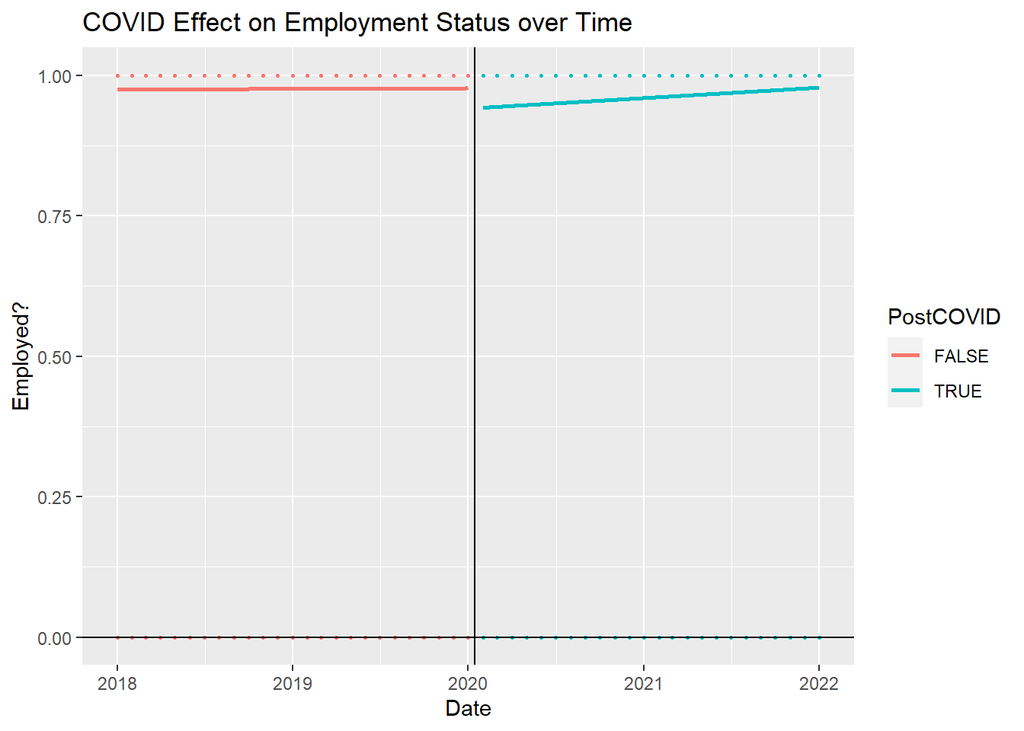

```r
empstatdf4 %>% mutate(date_group = as.factor(PostCOVID)) %>% ggplot(aes(x = Date, y = EMPSTAT, color = date_group)) + geom_point(size = 0.5) + geom_vline(xintercept = mdy(01152020)) + geom_smooth(method = "lm", se = FALSE) + ylim(0,1) + geom_hline(yintercept = 0) + labs(title = 'COVID Effect on Employment Status over Time', y = 'Employed?', color = 'PostCOVID')
```

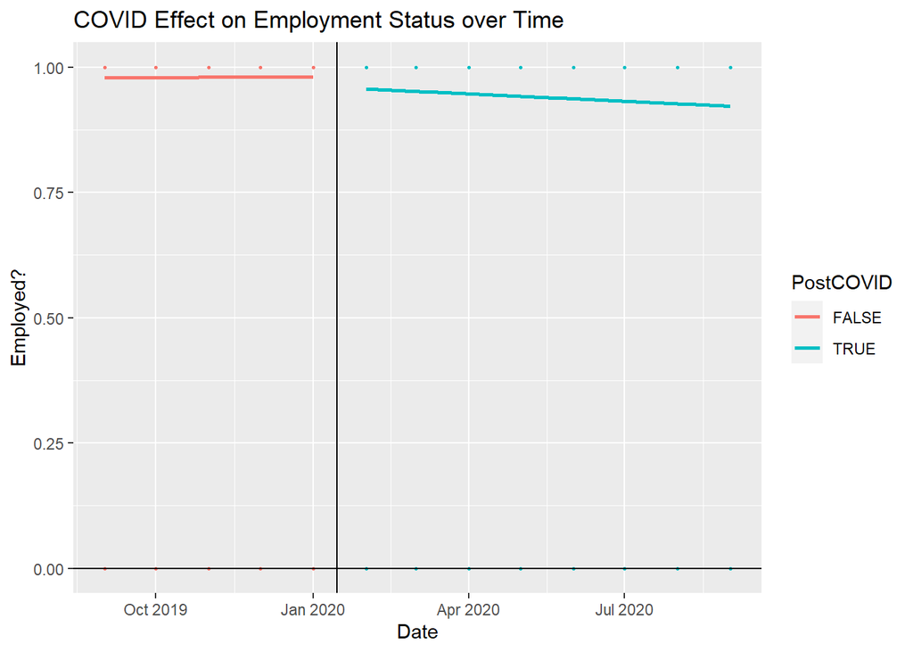

```r
empstatdf4 %>% mutate(date_group = as.factor(PostCOVID)) %>% ggplot(aes(x = Date, y = EMPSTAT, color = date_group)) + geom_point(size = 0.5) + geom_vline(xintercept = mdy(01152020)) + geom_smooth(method = "lm", se = FALSE) + ylim(0,1) + geom_hline(yintercept = 0) + labs(title = 'COVID Effect on Employment Status over Time', y = 'Employed?', color = 'PostCOVID') + xlim(mdy(09012019),mdy(09012020))
```

### 3.1.5 Arts, Entertainment, and Recreation, and Accommodation and Food Services Industry

```r
empstatdf5 <- empstatdf %>%
  filter(indname == 'Arts, Entertainment, and Recreation, and Accommodation and Food Services')

m16 <- lm(EMPSTAT ~ Date * PostCOVID, data = empstatdf5)
export_summs(m16)
```

|  | Model 1 |
| --- | --- |
| (Intercept) | 0.72 *** |
|  | (0.06) |
| Date | 0.00 *** |
|  | (0.00) |
| PostCOVIDTRUE | -3.20 *** |
|  | (0.09) |
| Date:PostCOVIDTRUE | 0.00 *** |
|  | (0.00) |
| N | 274534 |
| R2 | 0.03 |
| *** p < 0.001; ** p < 0.01; * p < 0.05. |  |

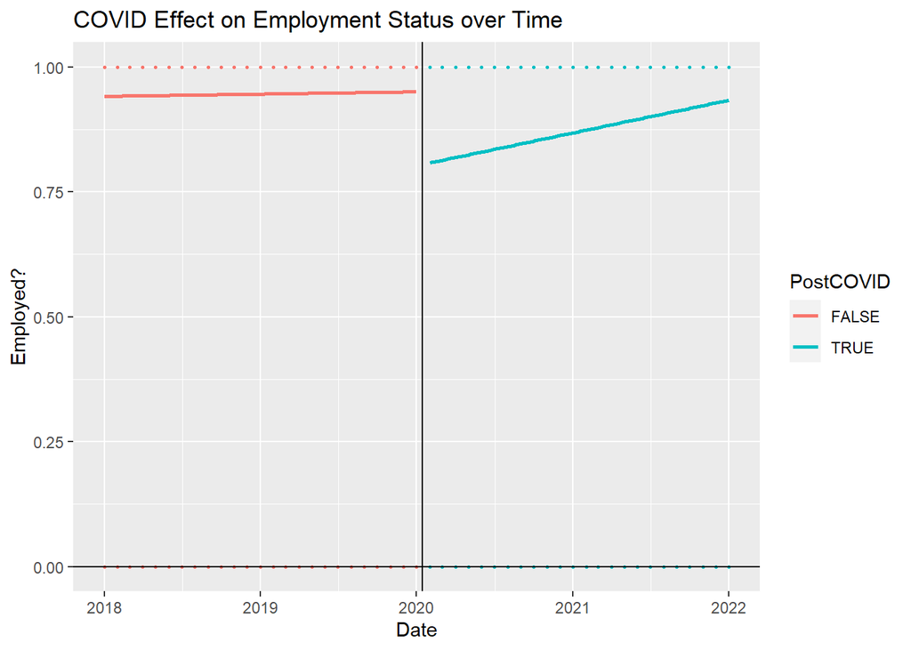

```r
empstatdf5 %>% mutate(date_group = as.factor(PostCOVID)) %>% ggplot(aes(x = Date, y = EMPSTAT, color = date_group)) + geom_point(size = 0.5) + geom_vline(xintercept = mdy(01152020)) + geom_smooth(method = "lm", se = FALSE) + ylim(0,1) + geom_hline(yintercept = 0) + labs(title = 'COVID Effect on Employment Status over Time', y = 'Employed?', color = 'PostCOVID')
```

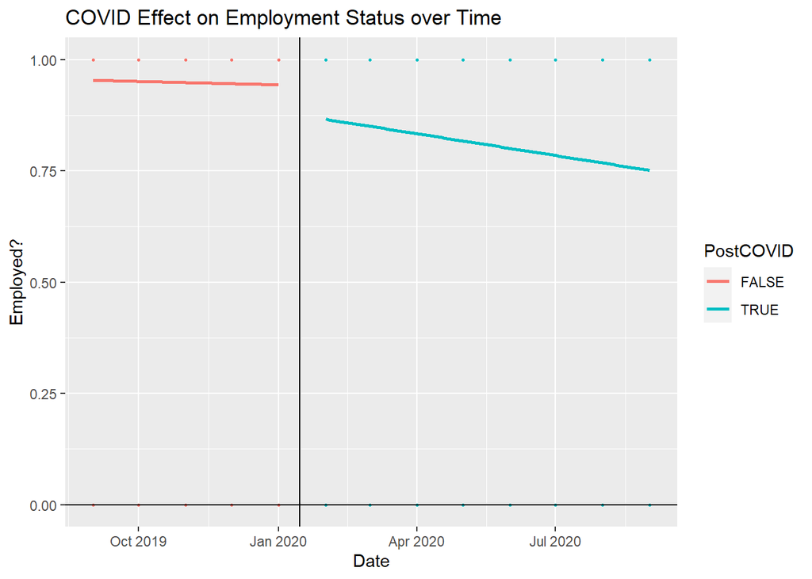

```r
empstatdf5 %>% mutate(date_group = as.factor(PostCOVID)) %>% ggplot(aes(x = Date, y = EMPSTAT, color = date_group)) + geom_point(size = 0.5) + geom_vline(xintercept = mdy(01152020)) + geom_smooth(method = "lm", se = FALSE) + ylim(0,1) + geom_hline(yintercept = 0) + labs(title = 'COVID Effect on Employment Status over Time', y = 'Employed?', color = 'PostCOVID') + xlim(mdy(09012019),mdy(09012020))
```

The interesting thing about this industry is in the short term, there’s a decrease in employment, but long-term, the industry recovers, as most of the industries do. This is one of the benefits of shortening the window we’re looking at.

### 3.1.6 Public Administration Industry

```r
empstatdf6 <- empstatdf %>%
  filter(indname == 'Public Administration')

m17 <- lm(EMPSTAT ~ Date * PostCOVID, data = empstatdf6)
export_summs(m17)
```

|  | Model 1 |
| --- | --- |
| (Intercept) | 0.95 *** |
|  | (0.04) |
| Date | 0.00 |
|  | (0.00) |
| PostCOVIDTRUE | -0.20 *** |
|  | (0.06) |
| Date:PostCOVIDTRUE | 0.00 ** |
|  | (0.00) |
| N | 157740 |
| R2 | 0.00 |
| *** p < 0.001; ** p < 0.01; * p < 0.05. |  |

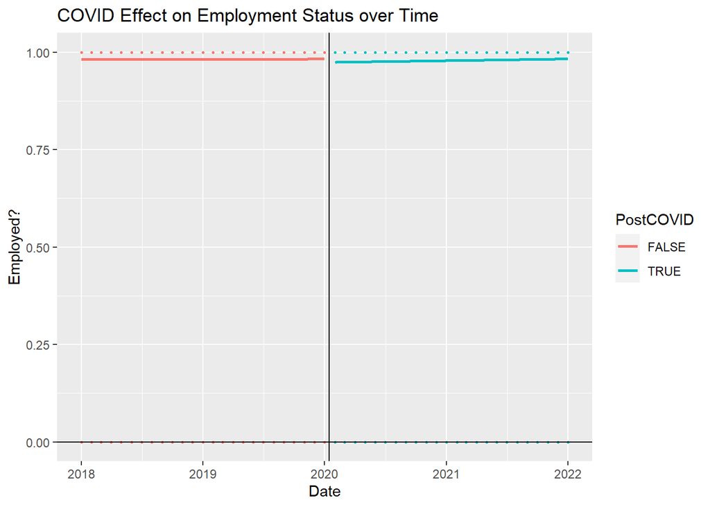

```r
empstatdf6 %>% mutate(date_group = as.factor(PostCOVID)) %>% ggplot(aes(x = Date, y = EMPSTAT, color = date_group)) + geom_point(size = 0.5) + geom_vline(xintercept = mdy(01152020)) + geom_smooth(method = "lm", se = FALSE) + ylim(0,1) + geom_hline(yintercept = 0) + labs(title = 'COVID Effect on Employment Status over Time', y = 'Employed?', color = 'PostCOVID')
```

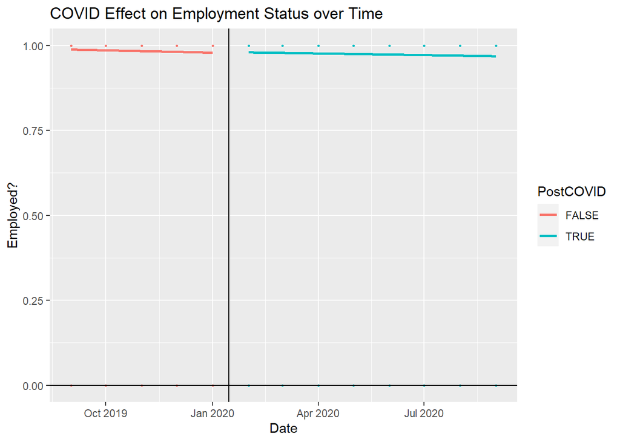

```r
empstatdf6 %>% mutate(date_group = as.factor(PostCOVID)) %>% ggplot(aes(x = Date, y = EMPSTAT, color = date_group)) + geom_point(size = 0.5) + geom_vline(xintercept = mdy(01152020)) + geom_smooth(method = "lm", se = FALSE) + ylim(0,1) + geom_hline(yintercept = 0) + labs(title = 'COVID Effect on Employment Status over Time', y = 'Employed?', color = 'PostCOVID') + xlim(mdy(09012019),mdy(09012020))
```

### 3.1.7 Agriculture, Forestry, Fishing, and Hunting, and Mining Industry

```r
empstatdf7 <- empstatdf %>%
  filter(indname == 'Agriculture, Forestry, Fishing, and Hunting, and Mining')

m18 <- lm(EMPSTAT ~ Date * PostCOVID, data = empstatdf7)
export_summs(m18)
```

|  | Model 1 |
| --- | --- |
| (Intercept) | 0.74 *** |
|  | (0.08) |
| Date | 0.00 ** |
|  | (0.00) |
| PostCOVIDTRUE | -0.15 |
|  | (0.13) |
| Date:PostCOVIDTRUE | 0.00 |
|  | (0.00) |
| N | 81880 |
| R2 | 0.00 |
| *** p < 0.001; ** p < 0.01; * p < 0.05. |  |

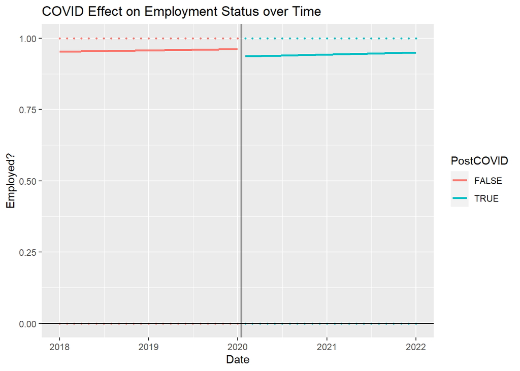

```r
empstatdf7 %>% mutate(date_group = as.factor(PostCOVID)) %>% ggplot(aes(x = Date, y = EMPSTAT, color = date_group)) + geom_point(size = 0.5) + geom_vline(xintercept = mdy(01152020)) + geom_smooth(method = "lm", se = FALSE) + ylim(0,1) + geom_hline(yintercept = 0) + labs(title = 'COVID Effect on Employment Status over Time', y = 'Employed?', color = 'PostCOVID')
```

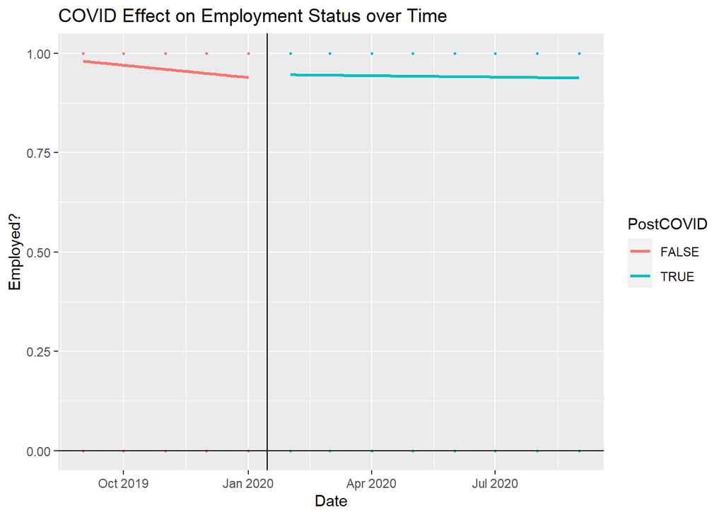

```r
empstatdf7 %>% mutate(date_group = as.factor(PostCOVID)) %>% ggplot(aes(x = Date, y = EMPSTAT, color = date_group)) + geom_point(size = 0.5) + geom_vline(xintercept = mdy(01152020)) + geom_smooth(method = "lm", se = FALSE) + ylim(0,1) + geom_hline(yintercept = 0) + labs(title = 'COVID Effect on Employment Status over Time', y = 'Employed?', color = 'PostCOVID') + xlim(mdy(09012019),mdy(09012020))
```

### 3.1.8 Transportation and Warehousing, and Utilities Industry

```r
empstatdf8 <- empstatdf %>%
  filter(indname == 'Transportation and Warehousing, and Utilities')

m19 <- lm(EMPSTAT ~ Date * PostCOVID, data = empstatdf8)
export_summs(m19)
```

|  | Model 1 |
| --- | --- |
| (Intercept) | 0.85 *** |
|  | (0.06) |
| Date | 0.00 * |
|  | (0.00) |
| PostCOVIDTRUE | -0.92 *** |
|  | (0.09) |
| Date:PostCOVIDTRUE | 0.00 *** |
|  | (0.00) |
| N | 169379 |
| R2 | 0.01 |
| *** p < 0.001; ** p < 0.01; * p < 0.05. |  |

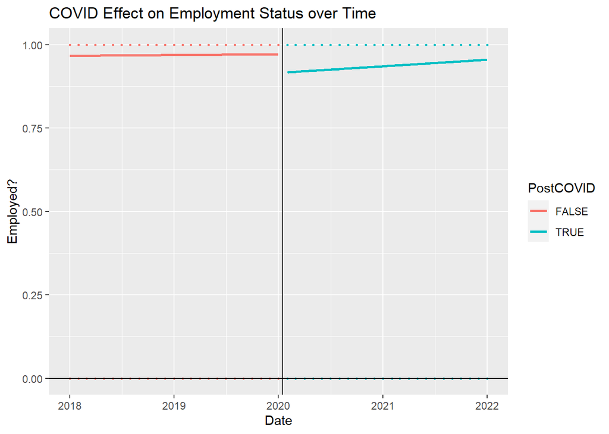

```r
empstatdf8 %>% mutate(date_group = as.factor(PostCOVID)) %>% ggplot(aes(x = Date, y = EMPSTAT, color = date_group)) + geom_point(size = 0.5) + geom_vline(xintercept = mdy(01152020)) + geom_smooth(method = "lm", se = FALSE) + ylim(0,1) + geom_hline(yintercept = 0) + labs(title = 'COVID Effect on Employment Status over Time', y = 'Employed?', color = 'PostCOVID')
```

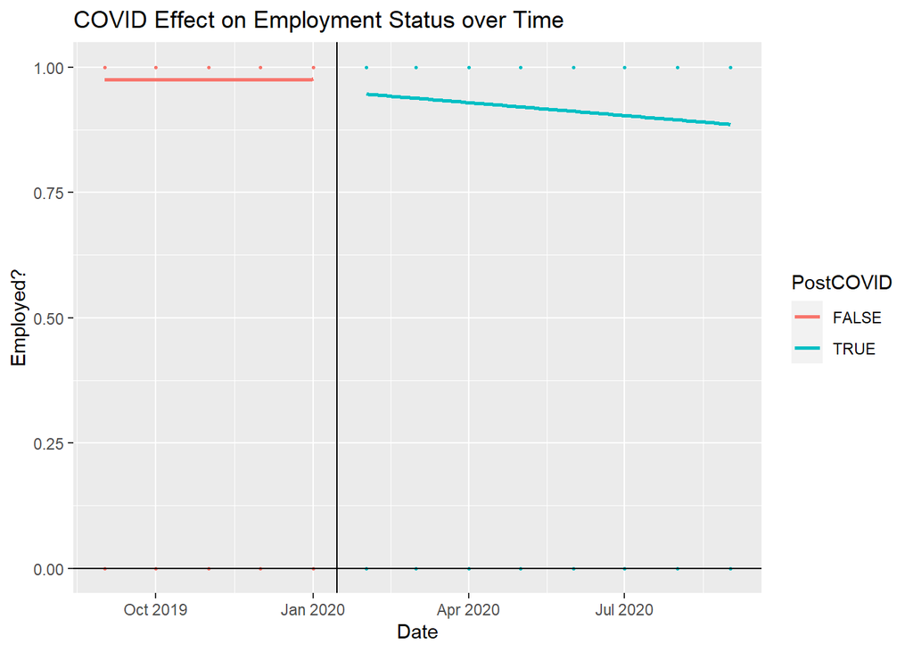

```r
empstatdf8 %>% mutate(date_group = as.factor(PostCOVID)) %>% ggplot(aes(x = Date, y = EMPSTAT, color = date_group)) + geom_point(size = 0.5) + geom_vline(xintercept = mdy(01152020)) + geom_smooth(method = "lm", se = FALSE) + ylim(0,1) + geom_hline(yintercept = 0) + labs(title = 'COVID Effect on Employment Status over Time', y = 'Employed?', color = 'PostCOVID') + xlim(mdy(09012019),mdy(09012020))
```

### 3.1.9 Construction Industry

```r
empstatdf9 <- empstatdf %>%
  filter(indname == 'Construction')

m20 <- lm(EMPSTAT ~ Date * PostCOVID, data = empstatdf9)
export_summs(m20)
```

|  | Model 1 |
| --- | --- |
| (Intercept) | 0.40 *** |
|  | (0.06) |
| Date | 0.00 *** |
|  | (0.00) |
| PostCOVIDTRUE | -0.47 *** |
|  | (0.09) |
| Date:PostCOVIDTRUE | 0.00 *** |
|  | (0.00) |
| N | 222307 |
| R2 | 0.00 |
| *** p < 0.001; ** p < 0.01; * p < 0.05. |  |

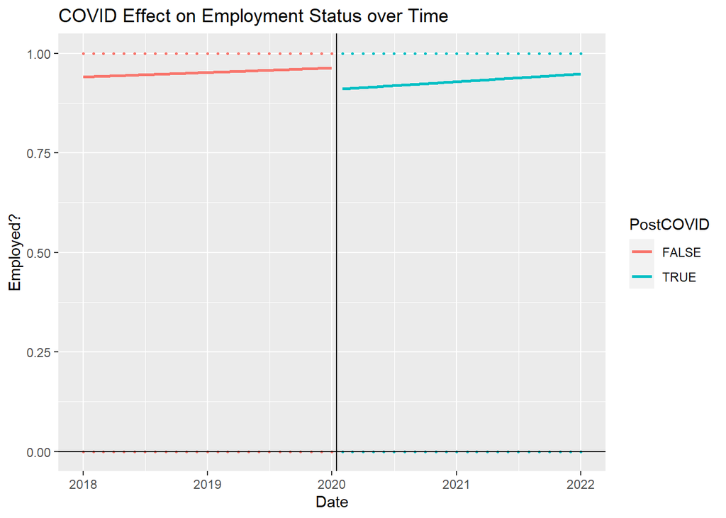

```r
empstatdf9 %>% mutate(date_group = as.factor(PostCOVID)) %>% ggplot(aes(x = Date, y = EMPSTAT, color = date_group)) + geom_point(size = 0.5) + geom_vline(xintercept = mdy(01152020)) + geom_smooth(method = "lm", se = FALSE) + ylim(0,1) + geom_hline(yintercept = 0) + labs(title = 'COVID Effect on Employment Status over Time', y = 'Employed?', color = 'PostCOVID')
```

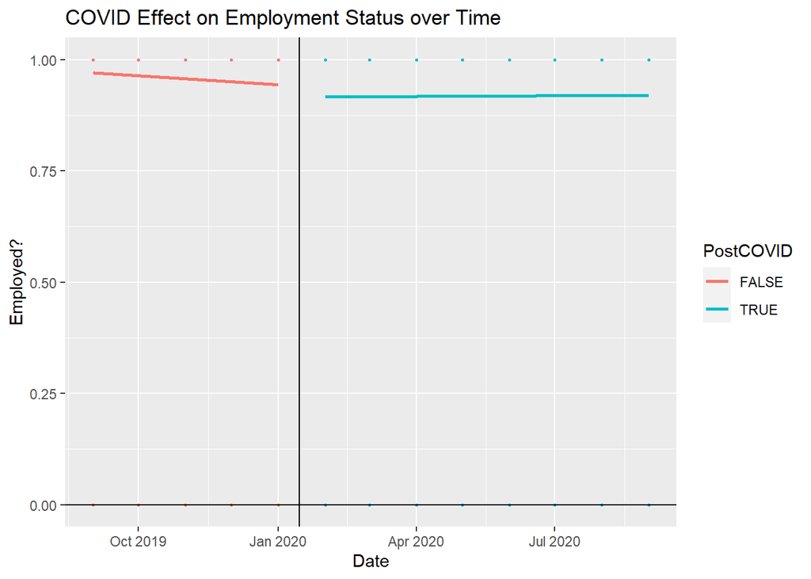

```r
empstatdf9 %>% mutate(date_group = as.factor(PostCOVID)) %>% ggplot(aes(x = Date, y = EMPSTAT, color = date_group)) + geom_point(size = 0.5) + geom_vline(xintercept = mdy(01152020)) + geom_smooth(method = "lm", se = FALSE) + ylim(0,1) + geom_hline(yintercept = 0) + labs(title = 'COVID Effect on Employment Status over Time', y = 'Employed?', color = 'PostCOVID') + xlim(mdy(09012019),mdy(09012020))
```

### 3.1.10 Manufacturing Industry

```r
empstatdf10 <- empstatdf %>%
  filter(indname == 'Manufacturing')

m21 <- lm(EMPSTAT ~ Date * PostCOVID, data = empstatdf10)
export_summs(m21)
```

|  | Model 1 |
| --- | --- |
| (Intercept) | 0.88 *** |
|  | (0.04) |
| Date | 0.00 * |
|  | (0.00) |
| PostCOVIDTRUE | -1.01 *** |
|  | (0.06) |
| Date:PostCOVIDTRUE | 0.00 *** |
|  | (0.00) |
| N | 293260 |
| R2 | 0.00 |
| *** p < 0.001; ** p < 0.01; * p < 0.05. |  |

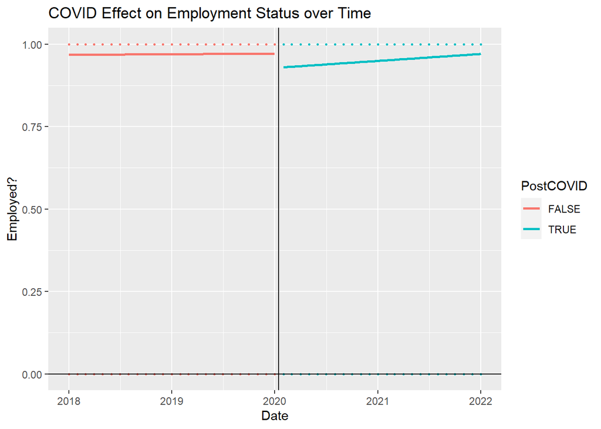

```r
empstatdf10 %>% mutate(date_group = as.factor(PostCOVID)) %>% ggplot(aes(x = Date, y = EMPSTAT, color = date_group)) + geom_point(size = 0.5) + geom_vline(xintercept = mdy(01152020)) + geom_smooth(method = "lm", se = FALSE) + ylim(0,1) + geom_hline(yintercept = 0) + labs(title = 'COVID Effect on Employment Status over Time', y = 'Employed?', color = 'PostCOVID')
```

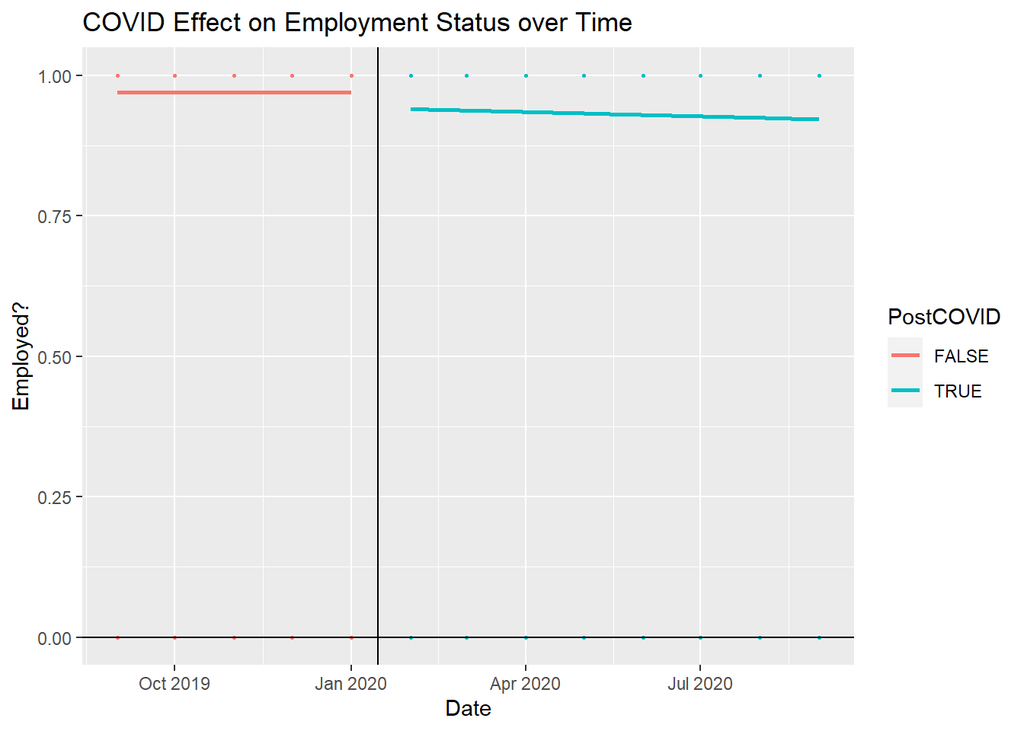

```r
empstatdf10 %>% mutate(date_group = as.factor(PostCOVID)) %>% ggplot(aes(x = Date, y = EMPSTAT, color = date_group)) + geom_point(size = 0.5) + geom_vline(xintercept = mdy(01152020)) + geom_smooth(method = "lm", se = FALSE) + ylim(0,1) + geom_hline(yintercept = 0) + labs(title = 'COVID Effect on Employment Status over Time', y = 'Employed?', color = 'PostCOVID') + xlim(mdy(09012019),mdy(09012020))
```

### 3.1.11 Other Services, Except Public Administration Industry

```r
empstatdf11 <- empstatdf %>%
  filter(indname == 'Other Services, Except Public Administration')

m22 <- lm(EMPSTAT ~ Date * PostCOVID, data = empstatdf11)
export_summs(m22)
```

|  | Model 1 |
| --- | --- |
| (Intercept) | 0.84 *** |
|  | (0.06) |
| Date | 0.00 * |
|  | (0.00) |
| PostCOVIDTRUE | -1.46 *** |
|  | (0.09) |
| Date:PostCOVIDTRUE | 0.00 *** |
|  | (0.00) |
| N | 148163 |
| R2 | 0.01 |
| *** p < 0.001; ** p < 0.01; * p < 0.05. |  |

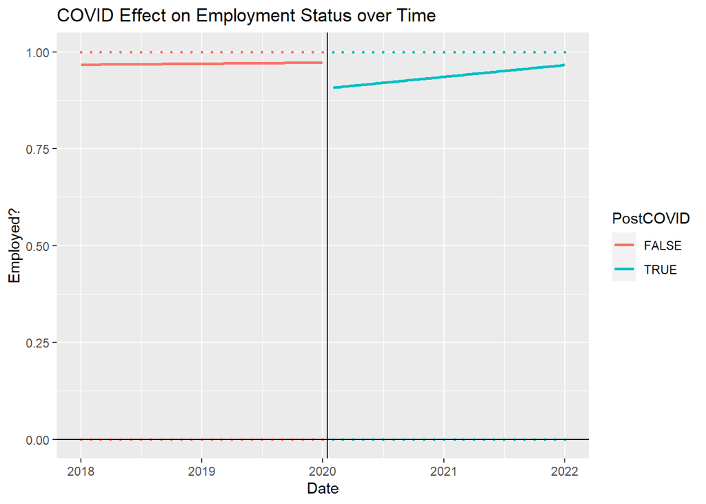

```r
empstatdf11 %>% mutate(date_group = as.factor(PostCOVID)) %>% ggplot(aes(x = Date, y = EMPSTAT, color = date_group)) + geom_point(size = 0.5) + geom_vline(xintercept = mdy(01152020)) + geom_smooth(method = "lm", se = FALSE) + ylim(0,1) + geom_hline(yintercept = 0) + labs(title = 'COVID Effect on Employment Status over Time', y = 'Employed?', color = 'PostCOVID')
```

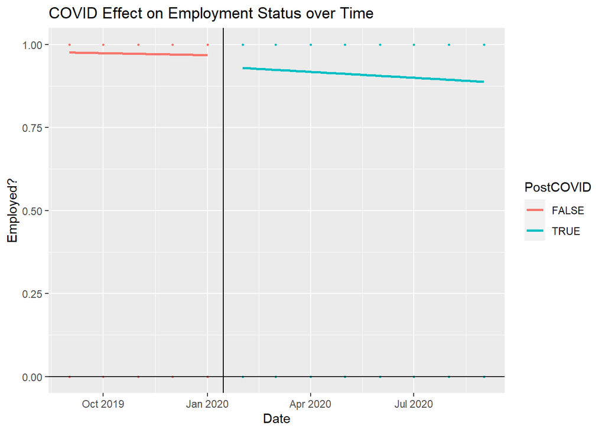

```r
empstatdf11 %>% mutate(date_group = as.factor(PostCOVID)) %>% ggplot(aes(x = Date, y = EMPSTAT, color = date_group)) + geom_point(size = 0.5) + geom_vline(xintercept = mdy(01152020)) + geom_smooth(method = "lm", se = FALSE) + ylim(0,1) + geom_hline(yintercept = 0) + labs(title = 'COVID Effect on Employment Status over Time', y = 'Employed?', color = 'PostCOVID') + xlim(mdy(09012019),mdy(09012020))
```

### 3.1.12 Wholesale Trade Industry

```r
empstatdf12 <- empstatdf %>%
  filter(indname == 'Wholesale Trade')

m23 <- lm(EMPSTAT ~ Date * PostCOVID, data = empstatdf12)
export_summs(m23)
```

|  | Model 1 |
| --- | --- |
| (Intercept) | 0.84 *** |
|  | (0.08) |
| Date | 0.00 |
|  | (0.00) |
| PostCOVIDTRUE | -0.43 *** |
|  | (0.12) |
| Date:PostCOVIDTRUE | 0.00 *** |
|  | (0.00) |
| N | 68110 |
| R2 | 0.00 |
| *** p < 0.001; ** p < 0.01; * p < 0.05. |  |

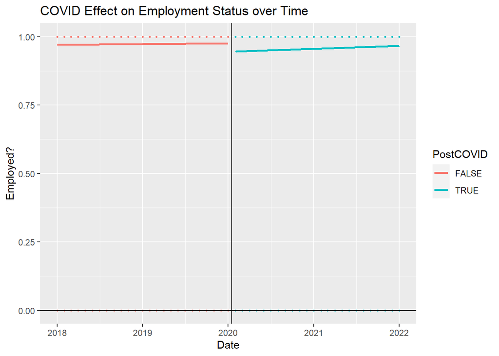

```r
empstatdf12 %>% mutate(date_group = as.factor(PostCOVID)) %>% ggplot(aes(x = Date, y = EMPSTAT, color = date_group)) + geom_point(size = 0.5) + geom_vline(xintercept = mdy(01152020)) + geom_smooth(method = "lm", se = FALSE) + ylim(0,1) + geom_hline(yintercept = 0) + labs(title = 'COVID Effect on Employment Status over Time', y = 'Employed?', color = 'PostCOVID')
```

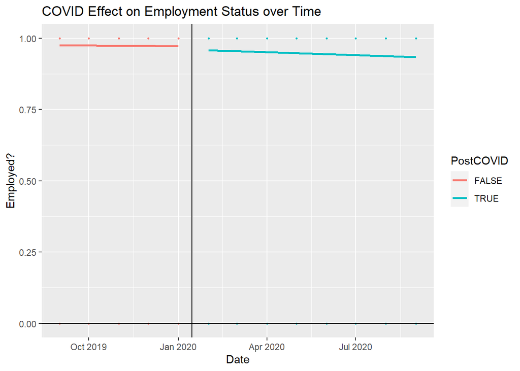

```r
empstatdf12 %>% mutate(date_group = as.factor(PostCOVID)) %>% ggplot(aes(x = Date, y = EMPSTAT, color = date_group)) + geom_point(size = 0.5) + geom_vline(xintercept = mdy(01152020)) + geom_smooth(method = "lm", se = FALSE) + ylim(0,1) + geom_hline(yintercept = 0) + labs(title = 'COVID Effect on Employment Status over Time', y = 'Employed?', color = 'PostCOVID') + xlim(mdy(09012019),mdy(09012020))
```

## 3.2 Conclusion - What has changed about who is working?

Our observation concludes that every industry experienced a similar trend in terms of unemployment. This was an initial loss in employment due to COVID, and then employment increased slowly around 2021. While some industries had pretty constant employment and some had a sharp cut, the earnings and employment variables across industries didn’t necessarily see a similar trend, for example, industries with a decrease in earnings did not always have a decrease in employment.

# 4 Final Conclusion

In conclusion, depending on when retail wanted to know the change, we can conclude that initially after the COVID date cutoff, manufacturing, construction, transportation, educational, and professional industries weren’t really affected negatively for earnings while every other industry was negative affected. Around a year after the COVID date cutoff, the earning per week returned back to Pre COVID results, except for the agriculture industry which remained stagnant. In 2022, the earning per week returned back to Pre COVID results if not greater except for the agriculture industry. This means the original industry leaders (finance, information, manufacturing, and other services and public administration) are still on the top for average earnings in 2022.

In terms of employment, every industry experienced the same trend in terms of unemployment. An initial loss in employment due to COVID. Then started to increase employment slowly around 2021. To eventually stabilize to prior employment back to Pre COVID rates in 2022. One thing to note is the arts industry had the biggest initial lost in employment at the start of the cutoff COVID date.

Some things to note about our data and our models:

There were a ton of observations on the first of each month, which makes it difficult to clearly see the effect of COVID, especially when it was declared a national pandemic. A lot can change month-to-month with lock-downs varying state-to-state and everywhere being on different timelines.

Also, our data does not take into account inflation from the years 2019 to now. This was not controlled for or adjusted for, so the coefficient on date for earnings may include inflation. This goes for raises year-to-year as well if applicable.

A lot of the models weren’t statistically significant when looking at weekly employee earnings. So, we cannot reject the null hypothesis that there was an effect on earnings from COVID for all industries.